# Homework - features and elements of multiple regression

# 1 MVP

1. Load the `diamonds.csv` data set and undertake an initial exploration of the data. You will find a description of the meanings of the variables on the relevant [Kaggle page](https://www.kaggle.com/shivam2503/diamonds/)

```r
diamonds <- read_csv("data/diamonds.csv")
library(GGally)
library(tidyverse)
glimpse(diamonds)
```

```
## Rows: 53,940
## Columns: 11
## $ X1      <dbl> 1, 2, 3, 4, 5, 6, 7, 8, 9, 10, 11, 12, 13, 14, 15, 16, 17, 18,…
## $ carat   <dbl> 0.23, 0.21, 0.23, 0.29, 0.31, 0.24, 0.24, 0.26, 0.22, 0.23, 0.…
## $ cut     <chr> "Ideal", "Premium", "Good", "Premium", "Good", "Very Good", "V…
## $ color   <chr> "E", "E", "E", "I", "J", "J", "I", "H", "E", "H", "J", "J", "F…
## $ clarity <chr> "SI2", "SI1", "VS1", "VS2", "SI2", "VVS2", "VVS1", "SI1", "VS2…
## $ depth   <dbl> 61.5, 59.8, 56.9, 62.4, 63.3, 62.8, 62.3, 61.9, 65.1, 59.4, 64…
## $ table   <dbl> 55, 61, 65, 58, 58, 57, 57, 55, 61, 61, 55, 56, 61, 54, 62, 58…
## $ price   <dbl> 326, 326, 327, 334, 335, 336, 336, 337, 337, 338, 339, 340, 34…
## $ x       <dbl> 3.95, 3.89, 4.05, 4.20, 4.34, 3.94, 3.95, 4.07, 3.87, 4.00, 4.…
## $ y       <dbl> 3.98, 3.84, 4.07, 4.23, 4.35, 3.96, 3.98, 4.11, 3.78, 4.05, 4.…
## $ z       <dbl> 2.43, 2.31, 2.31, 2.63, 2.75, 2.48, 2.47, 2.53, 2.49, 2.39, 2.…
```

2. We expect the `carat` of the diamonds to be strong correlated with the physical dimensions `x`, `y` and `z`. Use `ggpairs()` to investigate correlations between these four variables.

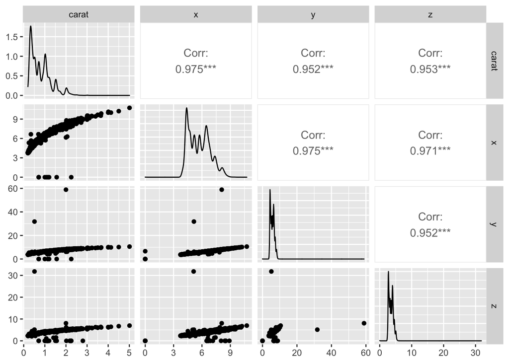

```r
ggpairs(diamonds[,c("carat", "x", "y", "z")])
```

3. So, we do find significant correlations. Let’s drop columns `x`, `y` and `z` from the dataset, in preparation to use only `carat` going forward.

```r
diamonds_tidy <- diamonds %>%
  select(-c("x", "y", "z"))

diamonds_tidy
```

| X1 | carat | cut | color | clarity | depth | table | price |
| --- | --- | --- | --- | --- | --- | --- | --- |
| 1 | 0.23 | Ideal | E | SI2 | 61.5 | 55.0 | 326 |
| 2 | 0.21 | Premium | E | SI1 | 59.8 | 61.0 | 326 |
| 3 | 0.23 | Good | E | VS1 | 56.9 | 65.0 | 327 |
| 4 | 0.29 | Premium | I | VS2 | 62.4 | 58.0 | 334 |
| 5 | 0.31 | Good | J | SI2 | 63.3 | 58.0 | 335 |
| 6 | 0.24 | Very Good | J | VVS2 | 62.8 | 57.0 | 336 |
| 7 | 0.24 | Very Good | I | VVS1 | 62.3 | 57.0 | 336 |
| 8 | 0.26 | Very Good | H | SI1 | 61.9 | 55.0 | 337 |
| 9 | 0.22 | Fair | E | VS2 | 65.1 | 61.0 | 337 |
| 10 | 0.23 | Very Good | H | VS1 | 59.4 | 61.0 | 338 |

[output cut: 9990 more lines]

4. We are interested in developing a regression model for the `price` of a diamond in terms of the possible predictor variables in the dataset.
1. Use `ggpairs()` to investigate correlations between `price` and the predictors (this may take a while to run, don’t worry, make coffee or something).

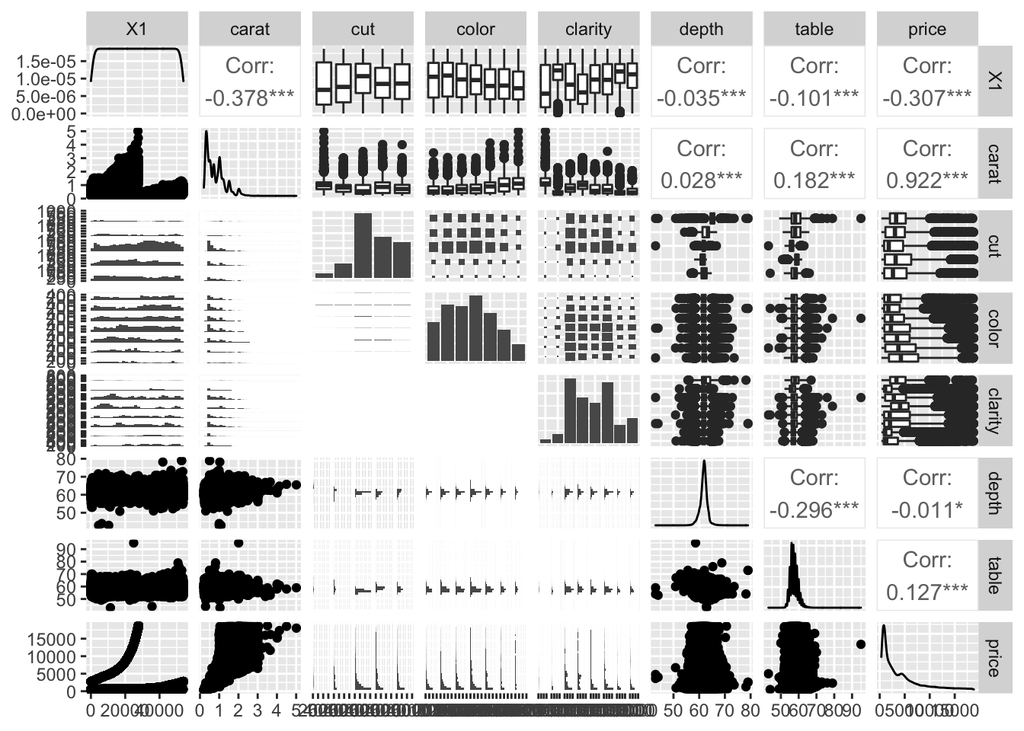

```r
ggpairs(diamonds_tidy)
```

`carat` is strongly correlated with `price`. Boxplots of `price` split by `cut`, `color` and particularly `clarity` also show some variation.

2. Perform further `ggplot` visualisations of any significant correlations you find.

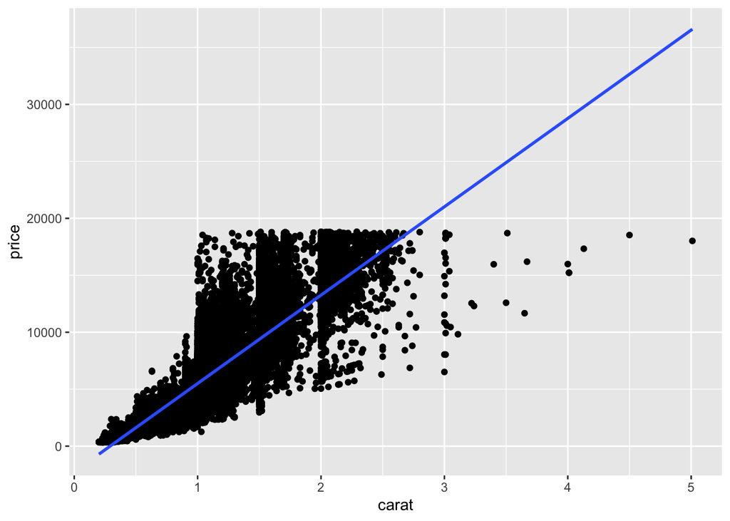

```r
diamonds_tidy %>%
  ggplot(aes(x = carat, y = price)) +
  geom_point() +
  geom_smooth(method = "lm", se = FALSE)
```

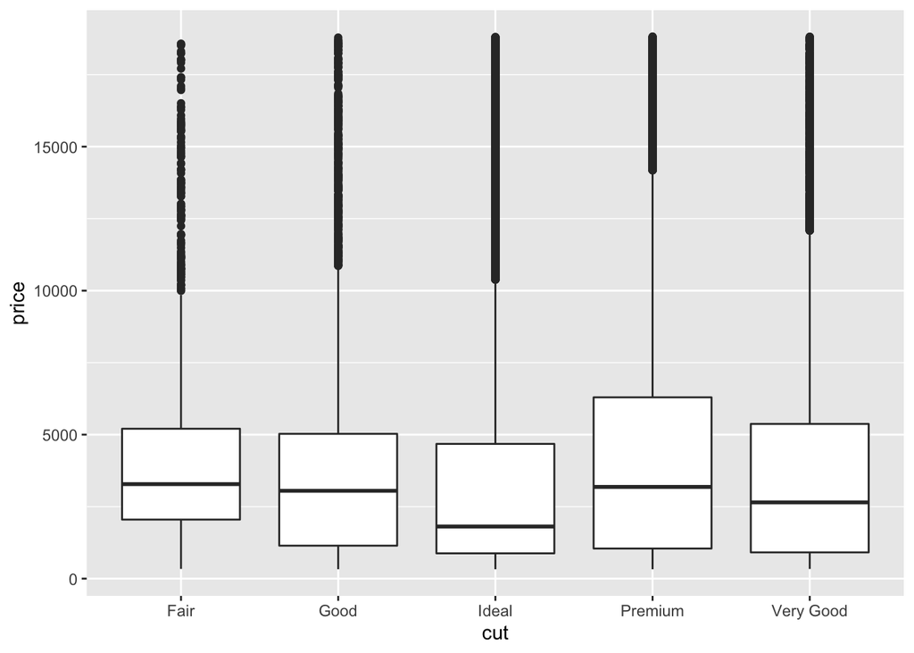

```r
diamonds_tidy %>%
  ggplot(aes(x = cut, y = price)) +
  geom_boxplot()
```

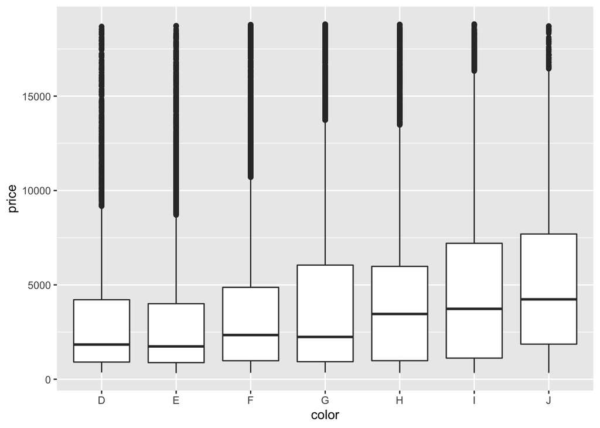

```r
diamonds_tidy %>%
  ggplot(aes(x = color, y = price)) +
  geom_boxplot()
```

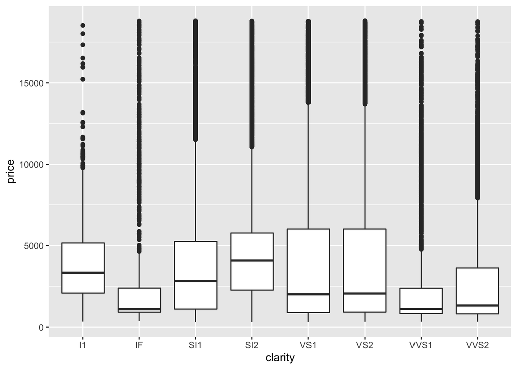

```r
diamonds_tidy %>%
  ggplot(aes(x = clarity, y = price)) +
  geom_boxplot()
```

5. Shortly we may try a regression fit using one or more of the categorical predictors `cut`, `clarity` and `color`, so let’s investigate these predictors. Investigate the levels of these predictors. How many dummy variables do you expect for each of them?

```r
unique(diamonds_tidy$cut)
```

```
## [1] "Ideal"     "Premium"   "Good"      "Very Good" "Fair"
```

```r
# expect 4 dummies for cut

unique(diamonds_tidy$color)
```

```
## [1] "E" "I" "J" "H" "F" "G" "D"
```

```r
# expect 6 dummies for color

unique(diamonds_tidy$clarity)
```

```
## [1] "SI2"  "SI1"  "VS1"  "VS2"  "VVS2" "VVS1" "I1"   "IF"
```

```r
# expect 7 dummies for clarity
```

6. Start with simple linear regression. Regress `price` on `carat` and check the regression diagnostics.

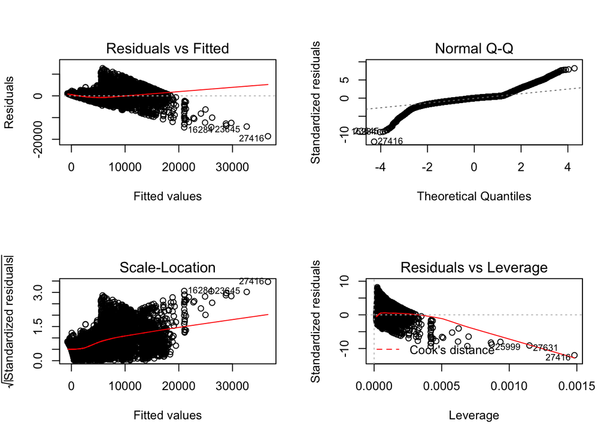

```r
mod1 <- lm(price ~ carat, data = diamonds_tidy)
par(mfrow = c(2,2))
plot(mod1)
```

```r
# the residuals show systematic variation, significant deviation from normality and heteroscedasticity. Oh dear...
```

7. Add another predictor of your choice. Check your assumptions, diagnostics, and interpret the model.

```r
mod2_clarity <- lm(price ~ carat + clarity, data = diamonds_tidy)
summary(mod2_clarity)
```

```
##
## Call:
## lm(formula = price ~ carat + clarity, data = diamonds_tidy)
##
## Residuals:
##      Min       1Q   Median       3Q      Max
## -17355.1   -639.9   -110.6    480.4  11162.8
##
## Coefficients:
##             Estimate Std. Error t value Pr(>|t|)
## (Intercept) -6911.57      50.22 -137.61   <2e-16 ***
## carat        8440.06      12.65  667.13   <2e-16 ***
## clarityIF    5513.14      57.37   96.11   <2e-16 ***
## claritySI1   3729.45      49.16   75.86   <2e-16 ***
## claritySI2   2879.18      49.47   58.20   <2e-16 ***
## clarityVS1   4613.76      50.13   92.03   <2e-16 ***
## clarityVS2   4388.90      49.38   88.88   <2e-16 ***
## clarityVVS1  5186.62      53.05   97.77   <2e-16 ***
## clarityVVS2  5163.32      51.62  100.02   <2e-16 ***
## ---
## Signif. codes:  0 '***' 0.001 '**' 0.01 '*' 0.05 '.' 0.1 ' ' 1
##
## Residual standard error: 1294 on 53931 degrees of freedom
## Multiple R-squared:  0.8949, Adjusted R-squared:  0.8948
## F-statistic: 5.737e+04 on 8 and 53931 DF,  p-value: < 2.2e-16
```

```r
# clarity leads to a model with highest r^2, all predictors are significant
```